# Problem Statement

```python
# Which movies have the highest budgets?
top_10_highest_budget_movies = df.sort_values(by='budget', ascending=False).head(10)
top_10_highest_budget_movies_df = top_10_highest_budget_movies[['title', 'budget']]
print(top_10_highest_budget_movies_df)
```

```
                                          title     budget
17  Pirates of the Caribbean: On Stranger Tides  380000000
1      Pirates of the Caribbean: At World's End  300000000
7                       Avengers: Age of Ultron  280000000
4                                   John Carter  260000000
6                                       Tangled  260000000
5                                  Spider-Man 3  258000000
13                              The Lone Ranger  255000000
19    The Hobbit: The Battle of the Five Armies  250000000
3                         The Dark Knight Rises  250000000
8        Harry Potter and the Half-Blood Prince  250000000
```

```python
df.sort_values('genres').head(10)
```

|  | index | budget | genres | homepage | id | keywords | original_language | original_title | overview | popularity | ... | tagline | title | vote_average | vote_count | cast | crew | director | release_ year | release_month | Profit |
| --- | --- | --- | --- | --- | --- | --- | --- | --- | --- | --- | --- | --- | --- | --- | --- | --- | --- | --- | --- | --- | --- |
| 750 | 750 | 60000000 | Action | http://www.stateofplaymovie.net/ | 16995 | corruption assassination detective journalist ... | en | State of Play | Handsome, unflappable U.S. Congressman Stephen... | 21.685719 | ... | Find The Truth | State of Play | 6.7 | 484 | Russell Crowe Ben Affleck Rachel McAdams Robin... | [{'name': 'Avy Kaufman', 'gender': 1, 'departm... | Kevin Macdonald | 2009 | 4 | 27784194 |
| 1398 | 1398 | 35000000 | Action | http://www.maxpaynethemovie.com | 13051 | assassin based on video game aftercreditsstinger | en | Max Payne | Coming together to solve a series of murders i... | 25.903237 | ... | When a Man Has Lost Everything. He Only has Re... | Max Payne | 5.2 | 613 | Mark Wahlberg Mila Kunis Beau Bridges Ludacris... | [{'name': 'Marco Beltrami', 'gender': 2, 'depa... | John Moore | 2008 | 10 | 50416905 |
| 1104 | 1104 | 40000000 | Action | http://www.thebountyhunter-movie.net/ | 27573 | bounty hunter ex-husband ex-wife relationship | en | The Bounty Hunter | Milo Boyd is a bounty hunter whose latest gig ... | 33.747825 | ... | It's a Job. It Isn't Personal. Well, Maybe a L... | The Bounty Hunter | 5.5 | 858 | Gerard Butler Jennifer Aniston Gio Perez Siobh... | [{'name': 'George Fenton', 'gender': 2, 'depar... | Andy Tennant | 2010 | 3 | 96000000 |
| 44 | 44 | 190000000 | Action | http://www.furious7.com/ | 168259 | car race speed revenge suspense car | en | Furious 7 | Deckard Shaw seeks revenge against Dominic Tor... | 102.322217 | ... | Vengeance Hits Home | Furious 7 | 7.3 | 4176 | Vin Diesel Paul Walker Dwayne Johnson Michelle... | [{'name': 'James Wan', 'gender': 2, 'departmen... | James Wan | 2015 | 4 | 1316249360 |
| 708 | 708 | 61000000 | Action | http://mazerunnermovies.com | 294254 | based on novel resistance maze post-apocalypti... | en | Maze Runner: The Scorch Trials | Thomas and his fellow Gladers face their great... | 113.161483 | ... | The Maze Was Just the Beginning. | Maze Runner: The Scorch Trials | 6.4 | 3040 | Dylan O'Brien Kaya Scodelario Thomas Brodie-Sa... | [{'name': 'Denise Chamian', 'gender': 1, 'depa... | Wes Ball | 2015 | 9 | 250256926 |
| 21 | 21 | 200000000 | Action Adventure | http://www.robinhoodthemovie.com/ | 20662 | robin hood archer knight sherwood forest bow a... | en | Robin Hood | When soldier Robin happens upon the dying Robe... | 37.668301 | ... | Rise and rise again, until lambs become lions. | Robin Hood | 6.2 | 1398 | Russell Crowe Cate Blanchett Max von Sydow Wil... | [{'name': 'Brian Grazer', 'gender': 2, 'depart... | Ridley Scott | 2010 | 5 | 110669540 |
| 469 | 469 | 75000000 | Action Adventure | http://www.sonypictures.com/homevideo/thelegen... | 1656 | california spy father son relationship mexico ... | en | The Legend of Zorro | Having spent the last 10 years fighting injust... | 31.054334 | ... | The original caped crusader is back! | The Legend of Zorro | 5.9 | 893 | Antonio Banderas Catherine Zeta-Jones Adri\u00... | [{'name': 'Lloyd Phillips', 'gender': 2, 'depa... | Martin Campbell | 2005 | 10 | 67400065 |
| 62 | 62 | 180000000 | Action Adventure | http://legendoftarzan.com | 258489 | africa feral child tarzan jungle animal attack | en | The Legend of Tarzan | Tarzan, having acclimated to life in London, i... | 42.741719 | ... | Human. Nature. | The Legend of Tarzan | 5.5 | 2430 | Alexander Skarsg\u00e5rd Margot Robbie Christo... | [{'name': 'Stuart Beattie', 'gender': 0, 'depa... | David Yates | 2016 | 6 | 176743061 |
| 152 | 152 | 145000000 | Action Adventure Animation Comedy Family | http://www.kungfupanda.com/ | 140300 | china martial arts kung fu village panda | en | Kung Fu Panda 3 | Continuing his "legendary adventures of awesom... | 56.747978 | ... | Grab destiny by the rice dumplings. | Kung Fu Panda 3 | 6.7 | 1603 | Jack Black Bryan Cranston Dustin Hoffman Angel... | [{'name': 'Guillermo del Toro', 'gender': 2, '... | Jennifer Yuh Nelson | 2016 | 1 | 376170825 |
| 339 | 339 | 92000000 | Action Adventure Animation Family | http://disney.go.com/disneyvideos/animatedfilm... | 9806 | secret identity secret hero island wretch | en | The Incredibles | Bob Parr has given up his superhero days to lo... | 77.817571 | ... | No gut, no glory | The Incredibles | 7.4 | 5152 | Craig T. Nelson Holly Hunter Samuel L. Jackson... | [{'name': 'John Lasseter', 'gender': 2, 'depar... | Brad Bird | 2004 | 11 | 539442092 |

10 rows × 27 columns

```python
popularity_desc =df.sort_values(by='popularity', ascending=False)
print(popularity_desc[['title', 'popularity']].head())
```

```
                       title  popularity
546                  Minions  875.581305
95              Interstellar  724.247784
788                 Deadpool  514.569956
94   Guardians of the Galaxy  481.098624
127       Mad Max: Fury Road  434.278564
```

## Aggregations(min,max,mean,mode,variance):

```python
#  Calculate aggregations for numeric columns

A =df.select_dtypes(include='number').agg(['min','max','mean','median','std','var'])
print("Aggregated Statistics for Numeric Columns:")

A
```

```
Aggregated Statistics for Numeric Columns:
```

|  | index | budget | id | popularity | revenue | runtime | vote_average | vote_count | release_ year | release_month | Profit |
| --- | --- | --- | --- | --- | --- | --- | --- | --- | --- | --- | --- |
| min | 0.000000e+00 | 0.000000e+00 | 1.100000e+01 | 0.023681 | 0.000000e+00 | 0.000000 | 0.000000 | 0.000000e+00 | 1937.000000 | 1.000000 | -1.657101e+08 |
| max | 4.796000e+03 | 3.800000e+08 | 3.940470e+05 | 875.581305 | 2.787965e+09 | 201.000000 | 8.400000 | 1.375200e+04 | 2016.000000 | 12.000000 | 2.550965e+09 |
| mean | 1.885148e+03 | 4.729039e+07 | 6.358191e+04 | 36.965023 | 1.603981e+08 | 109.231145 | 6.318156 | 1.373382e+03 | 2007.426676 | 6.905028 | 1.131077e+08 |
| median | 1.654500e+03 | 2.900000e+07 | 2.366850e+04 | 26.108374 | 6.807614e+07 | 106.000000 | 6.400000 | 6.660000e+02 | 2009.000000 | 7.000000 | 3.401279e+07 |
| std | 1.388674e+03 | 5.409809e+07 | 8.853175e+04 | 48.802540 | 2.440322e+08 | 19.018739 | 0.912928 | 1.812377e+03 | 8.442029 | 3.352886 | 2.071445e+08 |
| var | 1.928415e+06 | 2.926604e+15 | 7.837871e+09 | 2381.687886 | 5.955169e+16 | 361.712433 | 0.833437 | 3.284709e+06 | 71.267855 | 11.241848 | 4.290886e+16 |

```python
df.select_dtypes(include='number').agg([np.mean,np.median,np.amax,np.amin])
```

|  | index | budget | id | popularity | revenue | runtime | vote_average | vote_count | release_ year | release_month | Profit |
| --- | --- | --- | --- | --- | --- | --- | --- | --- | --- | --- | --- |
| mean | 1885.148045 | 4.729039e+07 | 63581.911313 | 36.965023 | 1.603981e+08 | 109.231145 | 6.318156 | 1373.381983 | 2007.426676 | 6.905028 | 1.131077e+08 |
| median | 1654.500000 | 2.900000e+07 | 23668.500000 | 26.108374 | 6.807614e+07 | 106.000000 | 6.400000 | 666.000000 | 2009.000000 | 7.000000 | 3.401279e+07 |
| amax | 4796.000000 | 3.800000e+08 | 394047.000000 | 875.581305 | 2.787965e+09 | 201.000000 | 8.400000 | 13752.000000 | 2016.000000 | 12.000000 | 2.550965e+09 |
| amin | 0.000000 | 0.000000e+00 | 11.000000 | 0.023681 | 0.000000e+00 | 0.000000 | 0.000000 | 0.000000 | 1937.000000 | 1.000000 | -1.657101e+08 |

```python
mode_values=df.select_dtypes(include='number').mode().values[0]
mode_values
```

```
array([0.0000e+00, 0.0000e+00, 1.1000e+01, 2.3681e-02, 0.0000e+00,
       1.0000e+02, 6.5000e+00, 6.0000e+00, 2.0110e+03, 9.0000e+00,
       0.0000e+00])
```

## Data Visualization:

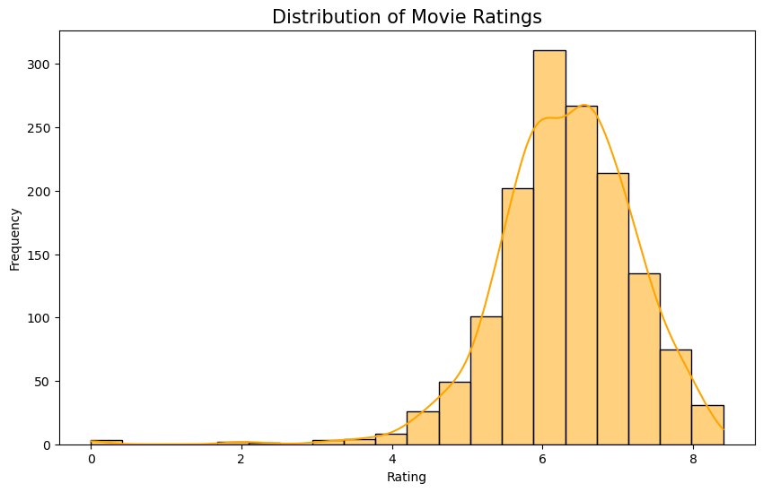

```python
# 1. What is the distribution of movie ratings by using histogram plot?

plt.figure(figsize=(10, 6))
sns.histplot(df['vote_average'], bins=20, kde=True ,color='Orange' )
plt.title('Distribution of Movie Ratings',fontsize=15)
plt.xlabel('Rating')
plt.ylabel('Frequency')
plt.show()
```

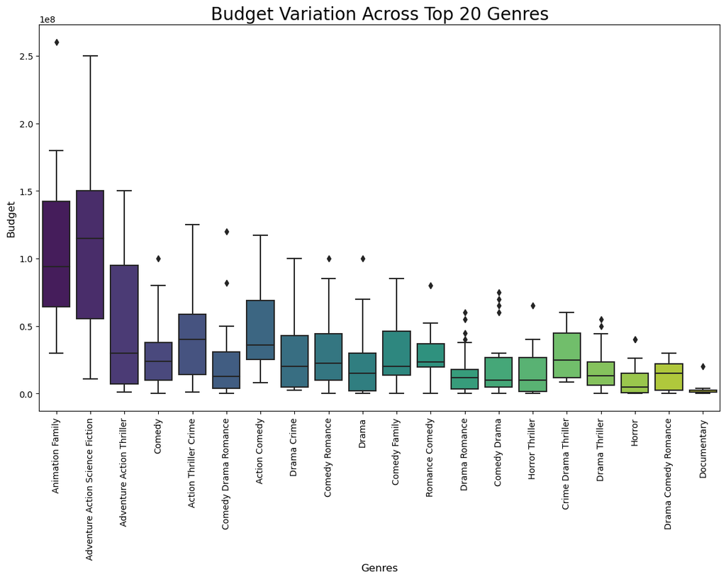

```python
# 2. How does the budget vary across top 20 different genres?

top_20_genres = df['genres'].value_counts().head(20).index
filtered_data = df[df['genres'].isin(top_20_genres)]
# Create a boxplot to show the budget variation across the top 20 genres
plt.figure(figsize=(14, 8))
sns.boxplot(x='genres', y='budget', data=filtered_data, palette='viridis')
plt.title('Budget Variation Across Top 20 Genres',fontsize=20)
plt.xlabel('Genres',fontsize=12)
plt.ylabel('Budget',fontsize=12)
plt.xticks(rotation=90)
plt.show()
```

- The boxplot indicates that there is substantial variation in budgets across genres. Some genres tend to have higher budgets on average, while others have lower budgets, reflecting the diversity in budget allocation within the movie industry.

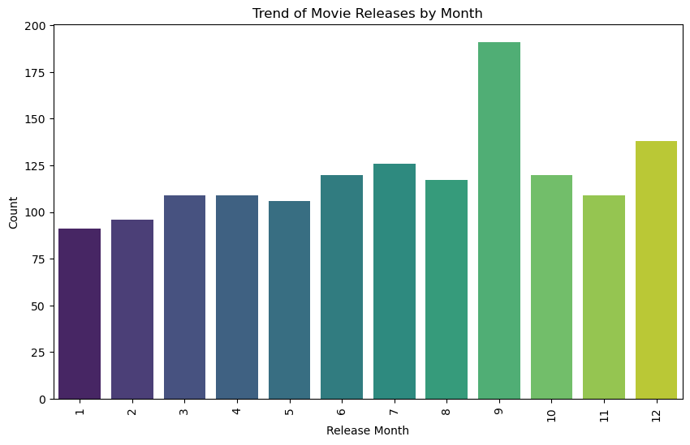

```python
#  3.Are there any trends in movie release months?

# Extract the month from the release_date column
df['release_month'] = df['release_date'].dt.month

plt.figure(figsize=(10, 6))
sns.countplot(x='release_month', data=df, palette='viridis')
plt.title('Trend of Movie Releases by Month')
plt.xlabel('Release Month')
plt.ylabel('Count')
plt.xticks(rotation=90)
plt.show()
```

- In september we have highest trend in release of movies.

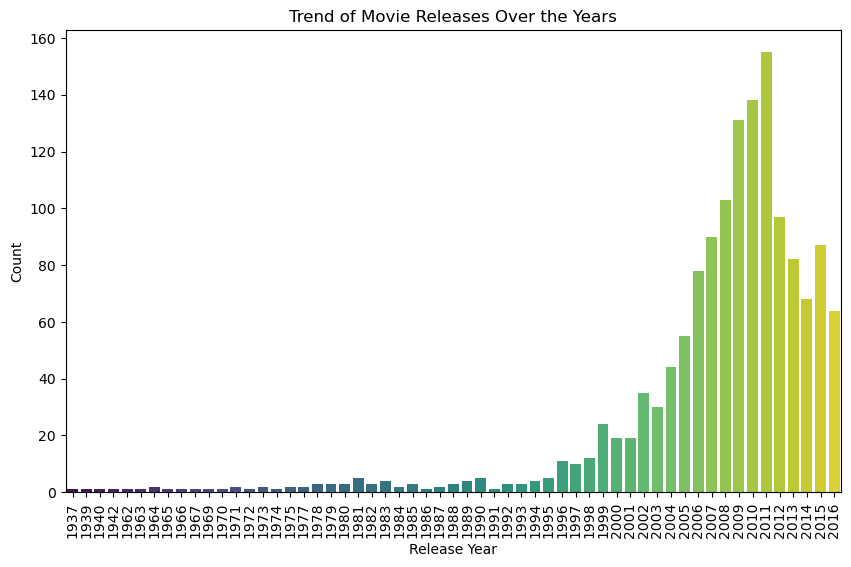

```python
# 4. What is the trend of movie releases over the years?

df['release_date'] = pd.to_datetime(df['release_date'])

df['release_ year'] = df['release_date'].dt.year
plt.figure(figsize=(10, 6))
sns.countplot(x='release_ year', data=df, palette='viridis')
plt.title('Trend of Movie Releases Over the Years')
plt.xlabel('Release Year')
plt.ylabel('Count')
plt.xticks(rotation=90)
plt.show()
```

- The countplot illustrates Movie production has generally increased over the years, with fluctuations in the number of releases.
- The 2000s and 2010s witnessed a significant rise in movie production, with the highest number of releases during those decades.
- There was a relatively lower number of movie releases in earlier decades, with a gradual increase in the 1980s.

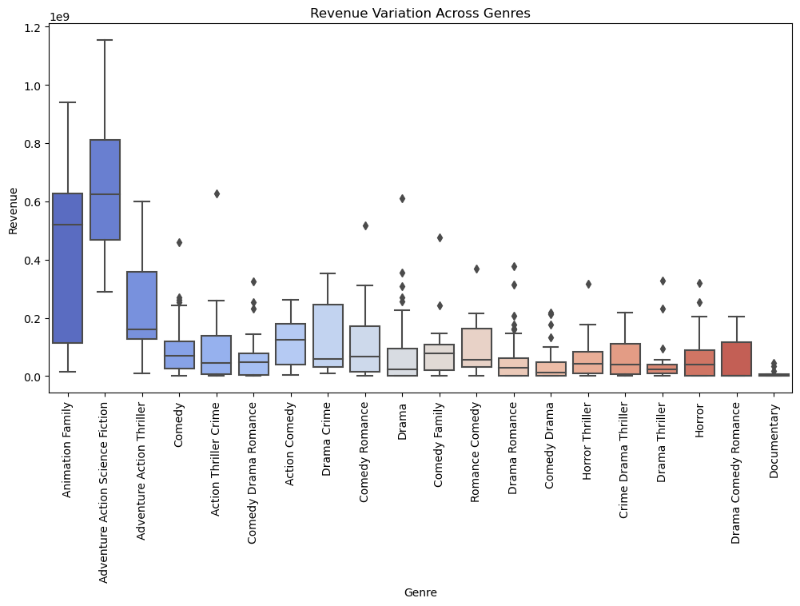

```python
# 5: How does the revenue vary across top 20 different genres?

filtered_data = df[df['genres'].isin(top_20_genres)]
plt.figure(figsize=(12, 6))
sns.boxplot(x='genres', y='revenue', data= filtered_data, palette='coolwarm')
plt.title('Revenue Variation Across Genres')
plt.xlabel('Genre')
plt.ylabel('Revenue')
plt.xticks(rotation=90)
plt.show()
```